# Introdução ao R para Bioinformática

### 2.6.1 Trabalhando com data.frames

Para acessar data.frames podemos usar os operadores `[]`, `[[]]` e `$`:

```r
dt<-data.frame(number=c(1, 2, 3, 4, 5),
               letter = c("x", "y", "z", "w", "j"),
               logical = c(TRUE, FALSE, FALSE, TRUE, FALSE))
# [[ ]] acessa cada coluna por posição
dt[[1]]
```

```
## [1] 1 2 3 4 5
```

```r
# [ ] acessa as coordenadas [linha, coluna]
dt[,1]
```

```
## [1] 1 2 3 4 5
```

```r
# $ acessa a coluna pelo nome
dt$number
```

```
## [1] 1 2 3 4 5
```

```r
# carrega o data.frame mtcars
cars<-mtcars
# mostra as 6 primeiras linhas
head(cars)
```

```
##                    mpg cyl disp  hp drat    wt  qsec vs am gear carb
## Mazda RX4         21.0   6  160 110 3.90 2.620 16.46  0  1    4    4
## Mazda RX4 Wag     21.0   6  160 110 3.90 2.875 17.02  0  1    4    4
## Datsun 710        22.8   4  108  93 3.85 2.320 18.61  1  1    4    1
## Hornet 4 Drive    21.4   6  258 110 3.08 3.215 19.44  1  0    3    1
## Hornet Sportabout 18.7   8  360 175 3.15 3.440 17.02  0  0    3    2
## Valiant           18.1   6  225 105 2.76 3.460 20.22  1  0    3    1
```

```r
# mostra as 6 ultimas linhas
tail(cars)
```

```
##                 mpg cyl  disp  hp drat    wt qsec vs am gear carb
## Porsche 914-2  26.0   4 120.3  91 4.43 2.140 16.7  0  1    5    2
## Lotus Europa   30.4   4  95.1 113 3.77 1.513 16.9  1  1    5    2
## Ford Pantera L 15.8   8 351.0 264 4.22 3.170 14.5  0  1    5    4
## Ferrari Dino   19.7   6 145.0 175 3.62 2.770 15.5  0  1    5    6
## Maserati Bora  15.0   8 301.0 335 3.54 3.570 14.6  0  1    5    8
## Volvo 142E     21.4   4 121.0 109 4.11 2.780 18.6  1  1    4    2
```

```r
# data.frames possuem colnames e rownames
colnames(dt)
```

```
## [1] "number"  "letter"  "logical"
```

```r
row.names(dt)
```

```
## [1] "1" "2" "3" "4" "5"
```

```r
# podemos alterar colnames e rownames
row.names(dt)<-c("a", "b", "c", "d", "e")
# alterando apenas a posição 2
colnames(dt)[2]<-"letras"
# podemos alterar valores específicos de um data.frame
dt[3,1]<-"10"
dt$logical<-as.numeric(dt$logical)
dt$letras<-NA
```

É possível verificar as ocorrencias de um data.frame em outro:

```r
biometria<-data.frame(nomes=c("Carlos", "Roberto", "Olivio", "Joel"),
                      altura=c(180, 187, 155, 168),
                      peso=c(80, 90, 98, 64))
biometria
```

```
##     nomes altura peso
## 1  Carlos    180   80
## 2 Roberto    187   90
## 3  Olivio    155   98
## 4    Joel    168   64
```

```r
esportes<-data.frame(nomes=c("Carlos", "Roberto", "Olivio", "Jomar"),
                     esportes=c("futebol", "remo", "sumo", "maratona"))
esportes
```

```
##     nomes esportes
## 1  Carlos  futebol
## 2 Roberto     remo
## 3  Olivio     sumo
## 4   Jomar maratona
```

```r
# retorna um vetor lógico
biometria$nomes %in% esportes$nomes
```

```
## [1]  TRUE  TRUE  TRUE FALSE
```

```r
# pode ser usado como índice
idx<-biometria$nomes %in% esportes$nomes
x<-biometria[idx,]
x
```

```
##     nomes altura peso
## 1  Carlos    180   80
## 2 Roberto    187   90
## 3  Olivio    155   98
```

```r
# ordenando data.frames por uma coluna
biometria<-biometria[with(biometria, order(altura)), ]
biometria
```

```
##     nomes altura peso
## 3  Olivio    155   98
## 4    Joel    168   64
## 1  Carlos    180   80
## 2 Roberto    187   90
```

Unindo data.frames com a função `merge()`:

```r
# independe da ordem dos data.frames
# a busca é feita pelo nome, não pela ordem
# o resultado sempre virá em ordem alfabética
unido<-merge(biometria, esportes, by="nomes")
unido
```

```
##     nomes altura peso esportes
## 1  Carlos    180   80  futebol
## 2  Olivio    155   98     sumo
## 3 Roberto    187   90     remo
```

```r
# as informações não disponíveis são preenchidas por NA
# com todos os presentes no primeiro
unido<-merge(biometria, esportes, by="nomes", all.x=T)
unido
```

```
##     nomes altura peso esportes
## 1  Carlos    180   80  futebol
## 2    Joel    168   64     <NA>
## 3  Olivio    155   98     sumo
## 4 Roberto    187   90     remo
```

```r
# com todos os presentes no segundo
unido<-merge(biometria, esportes, by="nomes", all.y=T)
unido
```

```
##     nomes altura peso esportes
## 1  Carlos    180   80  futebol
## 2   Jomar     NA   NA maratona
## 3  Olivio    155   98     sumo
## 4 Roberto    187   90     remo
```

```r
# com todos presentes
unido<-merge(biometria, esportes, by="nomes", all=T)
unido
```

```
##     nomes altura peso esportes
## 1  Carlos    180   80  futebol
## 2    Joel    168   64     <NA>
## 3   Jomar     NA   NA maratona
## 4  Olivio    155   98     sumo
## 5 Roberto    187   90     remo
```

# 3 Importação e exportação de dados

Uma das habilidades básicas necessárias para se fazer análises com o R é importar arquivos e fazer conexões com, por exemplo, bancos de dados, e exportar os resultados obtidos em formatos que possam ser lidos pela maioria dos softwares atuais.

## 3.1 Importando arquivos

Vamos aqui listar algumas funções úteis para a importação de arquivos no R.

- `source()`

A função `source()` carrega arquivos de scripts em R e executa os comandos ali contidos.

```r
# Caminho onde o script está salvo
source("/home/usuario/Área de Trabalho/script.R")
```

- `load()`

A função `load()` permite o carregamento de arquivos binários reconhecíveis pelo R. A extensão *.RData* é reconhecida pelo RStudio.

```r
# Caminho onde o .RData está salvo
load("/home/usuario/Área de Trabalho/arquivo.RData")
```

## 3.2 Importando dados tabulares

A principal função para importar dados tabulares (tabelas, planilhas, etc.) para o R é a `read.table()`. Esta função possui vários argumentos que podem ser modificados.  
Antes de carregar dados tabulares no R, é importante saber como o dado está organizado (se a separação entre as colunas é feita por tabulação ou por vírgula, por exemplo.)

Alguns argumentos cuja modificação pode ser útil para a importação da tabela:

- `file`: caminho do diretório onde o arquivo está.
- `header`: se `FALSE`, não considera o cabeçalho (se houver) da tabela
- `sep`: como o dado está separado. Se por tabulação, `sep = "\t"`, se por vírgula, `sep = ","`
- `dec`: como os números decimais são definidos, se com “.” ou “,”.
- `col.names` e `row.names`: recebem um vetor contendo os nomes das colunas e das linhas, respectivamente.
- `quote`: atribui um caracter para as aspas. Por padrão, atribui ““.
- `comment.char`: atribui um caracter para ser usado como comentário.
- `skip`: valor numérico. Pula a importação da quantidade definida de linhas.
- `stringsAsFactors`: se uma das colunas da tabela for um vetor de caracteres, a opção `TRUE` a considera como um vetor de fatores.

Outras duas funções bastante utilizadas são derivadas da função `read.table()`. Estas possuem os mesmos argumentos da função `read.table()`.

- `read.delim()`: por default, considera o argumento `sep = "\t"`. Útil para a importação de arquivos cujos elementos são separados por tabulações.
- `read.csv()`: por default, considera o argumento `sep = ","`. Útil para leitura de arquivos *.csv*.

## 3.3 Importando arquivos de estrutura desconhecida

Quando lidamos com arquivos dos quais desconhecemos a sua estrutura, podemos dispor de algumas estratégias para facilitar a importação deles para o R.

Podemos usar a função `readLines()`. Esta função pode abrir uma conexão (ver adiante) com um arquivo e ler o conteúdo de suas linhas. A saída da função é um vetor de caracteres, onde o conteúdo de cada linha do arquivo original compreenderá uma posição do vetor de saída. Este procedimento pode revelar como o dado está organizado: se é um dado tabulado, como os elementos de cada coluna estão separados, etc.

```r
# Irá ler as 10 primeiras linhas do arquivo
readLines("COG.mappings.v9.0.txt", 10)
```

Uma outra forma de desvendar a estrutura de um arquivo é usando a função `scan()`. A saída da função `scan()` é um vetor de caracteres onde cada string do arquivo original compreenderá uma posição do vetor de saída.

```r
scan(file = 'COG.mappings.v9.0.txt', nlines = 10, what = character())
```

## 3.4 Conexões

As funções citadas anteriormente tem em comum a capacidade de abrirem conexões com arquivos e extraírem as informações neles contidas. Além destas, o R possui muitas outras funções para lidar com outros tipos de arquivos e dados externos ao R.

Pode-se também estabelecer conexões com sites da web:

```r
# url() abre uma conexão com arquivo web
con <- url("http://www.tribunadonorte.com.br/", "r", 10)
x <- readLines(con)
x[1:10]
close(con)
```

## 3.5 Salvando arquivos

Os objetos do R podem ser salvos em arquivos *.RData* por meio da função `save()`. Uma quantidade indeterminada de objetos podem ser salvos no mesmo arquivo *.RData*.

```r
save(unido, biometria, esportes, file = "arquivo.RData")
```

Outra funcionalidade útil é a exportação de objetos tabulares do R para arquivos de texto. Para isso, usamos a função `write.table()`. Esta função possui argumentos semelhantes aos da função `read.table()`.

Ao usar a função `write.table()`, é importante definir o diretório no qual o arquivo será salvo e o tipo de separador usado para separar os elementos (argumento `sep`). Segue a seguinte estrutura:

```r
write.table(<objeto>, file = <diretório de destino>, sep = <separador>)
```

Exemplo:

```r
write.table(table1, file = "arquivo.txt", sep = "\t", row.names = FALSE, quote = FALSE)
```

Além disso, também como a função `read.table()`, `write.table()` possui outras funções genéricas como `write.csv()`, por exemplo, a qual possui o argumento `sep = ","` por default.

# 4 Definindo funções em R

A capacidade de escrever funções otimiza a execução de tarefas repetitivas e torna o usuário um desenvolvedor de conteúdo.

## 4.1 Aspectos gerais das funções em R

Uma função é um objeto capaz de realizar uma ação. Por exemplo, a função `mean()` obtém a média de um vetor numérico e a função `sqrt()` realiza o cálculo da raiz quadrada de cada elemento de um vetor numérico.

- Funções podem ser usadas de forma encadeada. O resultado de uma função é usado pela função mais externa:

```r
# O resultado da função unique() é usado pela função length()
length(unique(mtcars$cyl))
```

## 4.2 Fazendo a correspondência dos argumentos nas funções

A correspondência dos argumentos de uma função pode ser feita por meio do **nome do argumento** ou por meio da **posição**. Vamos tomar como exemplo a função `rnorm()`, que gera um vetor de *n* elementos que possui valores que obedecem à distribuição normal.

A função possui 3 argumentos: `n` (tamanho do vetor a ser criado), `mean` (média da distribuição) e `sd` (desvio padrão da distribuição), nesta ordem. Se os nome dos argumentos não forem definidos na chamada da função, ela assumirá que o primeiro argumento corresponde ao *n*, o segundo ao *mean* e o terceiro ao *sd*.

Vamos criar um vetor de 100 elementos com média 1 e desvio padrão 2.

```r
# Argumentos da função rnorm
args(rnorm)
```

```
## function (n, mean = 0, sd = 1)
## NULL
```

```r
# Fazendo a correspondência pela posição dos argumentos
rnorm(100, 1, 2)
```

```r
# Fazendo a correspondência pelo nome dos argumentos
rnorm(mean = 1, n = 100, sd = 2)
```

Ambas as utilizações irão gerar e mesmo resultado.

Observe, ainda, que as funções podem apresentar argumentos que já possuem uma valor pré-definido. Na função `rnorm()`, os argumentos `mean()` e `sd()` possuem valores pré-definidos.

```r
# A função irá executar mesmo sem o fornecimento dos outros argumentos.
rnorm(n = 100)
```

Entretanto, observe que o argumento `n` não possui valor pré-definido. A ausência deste argumento impossibilita a execução da função.

```r
rnorm()
```

```
## Error in rnorm(): argument "n" is missing, with no default
```

## 4.3 Anatomia das funções em R

As funções possuem três elementos primordiais:

- Argumentos: parâmetros que possibilitam a execução da ação. Ao definir a função, os argumentos podem assumir qualquer nome;
- Corpo: sequência de passos para resultar no objetivo da função;
- Ambiente: quando uma função é definida, ela cria um ambiente pŕoprio, onde as variáveis criadas dentro dela possuem valores próprios.

### 4.3.1 Definindo funções

Algumas propriedades das funções:

- A função `function()` cria funções definidas pelo próprio usuário:

```r
my_fun <- function(arg1, arg2) { # Argumentos
    # Corpo da função
}
```

- As funções podem ter uma quantidade indeterminada de argumentos e, inclusive, não apresentar argumentos:

```r
# Imprime 12. Não possui argumentos.
f <- function() {
      12
}
f()
```

```
## [1] 12
```

```r
# Simplesmente imprime "BU!" com qualquer argumento.
f1 <- function(x) {
      "BU!"
}
f1()
```

```
## [1] "BU!"
```

- Os argumentos das funções podem apresentar um valor pré-definido:

```r
# y possui um valor pré-definido
f2 <- function(x, y = 10) {
      x + y
}
f2(2)
```

```
## [1] 12
```

```r
f2(2, 4)
```

```
## [1] 6
```

- Quando definimos um objeto dentro de uma função e este representa o resultado final da função, é necessário retornar seu valor. Para isso, podemos usar a função `return()` ou `print()`:

```r
# Imprimir o resultado calculado
f3 <- function(a, b) {
      res <- c()
      res[1] <- a^2
      res[2] <- b + 1
      print(res)
}
f3(2, 4)
```

```
## [1] 4 5
```

- Funcões podem existir dentro de outras funções:

```r
make.power <- function(n) {
      pow <- function(x) {
            x^n
      }
      pow
}

cube <- make.power(3)
square <- make.power(2)

cube(3)
```

```
## [1] 27
```

```r
square(2)
```

```
## [1] 4
```

## 4.4 Ambientes e escopo das funções

Antes de qualquer coisa, precisamos entender o conceito de variáveis livres. As variáveis livres são variáveis que não são argumentos das funções e nem foram definidas dentro da função (no escopo da função). As regras de escopo definem como o R irá tentar buscar o valor correspondente a essa variável livre. Por exemplo:

```r
fun <- function(x, y) {
    x + y + z
}
```

A função acima possui a variável *z*, porém ela não foi definida nem como argumento nem no escopo da função.

Ambientes correspondem a um conceito abstrato para definir um conjunto de objetos. O ambiente mais usado interativamente pelo usuário é o *Global Environment* ou ambiente global, que guarda as objetos e funções que construímos em uma sessão do R. Quando estamos trabalhando no console e queremos obter o valor de um objeto, o R irá procurar pelo objeto primeiramente no ambiente global e, se não encontrar, irá procurar nos outros ambientes.

Para se ter uma ideia de quantos e quais os ambientes podem existir, podemos usar a função `search()`.

```r
search()
```

```
##  [1] ".GlobalEnv"        "package:BiocStyle" "package:stats"
##  [4] "package:graphics"  "package:grDevices" "package:utils"
##  [7] "package:datasets"  "package:methods"   "Autoloads"
## [10] "package:base"
```

Tendo em vista a ideia de ambiente, consideremos a função `fun()` definida anteriormente. O valor da variável *z* é buscado inicialmente no escopo da função, em seguida no ambiente global e, se não encontrado, é buscado nos outros ambientes. Se, após o término da busca, o valor desta variável não for encontrado, a função retornará um erro:

```r
fun <- function(x, y) {
    x + y + z
}
fun(1, 3)
```

```
## Error in fun(1, 3): object 'z' not found
```

Mais exemplos:

```r
f4 <- function(x, y) {
      x^2 + y/z
}
f4(2, 4)
```

```
## Error in f4(2, 4): object 'z' not found
```

No caso a seguir, o valor da variável *z* é definido no ambiente global e possibilita a execução da função.

```r
z <- 3
f4 <- function(x, y) {
      x^2 + y/z
}
f4(2, 4)
```

```
## [1] 5.333333
```

## 4.5 Outros exemplos

Criando uma função para adicionar dois números:

```r
# x e y são os argumentos da função definida
# O que a função faz: adiciona dois números
add_num <- function(x, y) {
    x + y
}
add_num(x = 2, y = 3)
```

```
## [1] 5
```

Criando uma função para calcular a média de um vetor numérico:

```r
calc_media <- function(vetor) {
    sum(vetor)/length(vetor)
}
calc_media(c(1, 2, 3, 4))
```

```
## [1] 2.5
```

Criando uma função que obtenha os valores extremos de um vetor numérico:

```r
# Após criar uma variável dentro do escopo da função, devemos retornar o valor da variável.
obter_extremos <- function(vetor) {
    res <- c(min(vetor, na.rm = TRUE), max(vetor, na.rm = TRUE))
    print(res)
}
obter_extremos(c(1, 2, 3, 4))
```

```
## [1] 1 4
```

# 5 Estruturas de controle

As estruturas de controle permitem a execução de um conjunto de ações seguindo uma ordem lógica. Elas são usadas principalmente quando construímos funções ou expressões mais extensas.

## 5.1 `if` / `else`

Estas estruturas testam se uma condição é verdadeira e desenvolvem ações a partir desta avaliação.

O controle do fluxo do código é feito por alguns operadores lógicos:

| Metacaractere | Funcionalidade |
| --- | --- |
| & | Retorna TRUE se todas as expressões forem TRUE |
| && | Avalia apenas o primeiro elemento, retorna TRUE se a expressão for TRUE |
| \| | Retorna TRUE se pelo menos um elemento da expressão for TRUE |
| \|\| | Avalia apenas o primeiro elemento, retorna TRUE se um dos elementos for TRUE |
| ! | Inverte o valor lógico |

Estrutura geral:

```r
if (condition) {
    # Executar caso a condição acima seja verdadeira
} else {
    # Executar caso a condição acima seja falsa
}
```

- Pode-se usar apenas o `if`. Neste caso, se a condição for falsa, nenhuma ação será executada:

```r
x <- 10
if (x < 20) {
    print("Hello!")
}
```

```
## [1] "Hello!"
```

```r
x <- 30
if (x < 20) {
    print("Hello!")
}
```

- Executar uma ação quando a condição for verdadeira e outra quando esta for falsa:

```r
# Se x for maior de que 10 a função fará a raiz quadrada de x
x <- 12
if (x > 10) {
    sqrt(x)
} else {
    x^2
}
```

```
## [1] 3.464102
```

- Executar ações quando há mais condições envolvidas:

```r
if (x > 15) {
      sqrt(x)
} else if (x <= 15 & x > 10) {
      x
} else {
      x^2
}
```

```
## [1] 12
```

- Usando `if`/`else` para definir uma função:

```r
humor <- function(salario) {
      if (salario > 10000) {
            print(":)")
      } else {
            print(":(")
      }
}
humor(7000)
```

```
## [1] ":("
```

```r
humor(12000)
```

```
## [1] ":)"
```

- Existe ainda a função `ifelse`, que apresenta a seguinte estrutura:

```r
ifelse( <condição>, <executar, se verdadeiro>, <executar, se falso>)
```

```r
humor1 <- function(salario) {
    ifelse(salario > 10000, ":)", ":(")
}
humor1(7000)
```

```
## [1] ":("
```

```r
humor1(12000)
```

```
## [1] ":)"
```

```r
humor2 <- function(salario) {
    ifelse(salario > 10000, ":)", ifelse(salario <= 10000 & salario > 5000, ":|", ":("))
}
humor2(4000)
```

```
## [1] ":("
```

```r
humor2(7000)
```

```
## [1] ":|"
```

```r
humor2(12000)
```

```
## [1] ":)"
```

## 5.2 `for` loop

O `for` loop realiza uma ação por uma quantidade definida de vezes.

Estrutura geral:

- ‘i’ corresponde ao índice do elemento da sequência, ‘1:x’ cria uma sequência:

```r
for (i in 1:x) {
    # Executar comandos tantas vezes quantos elementos houverem na sequência
}
```

Exemplos:

```r
# A função imprime os resultados subsequentemente
for (i in 1:10){
      print(i)
}
```

```
## [1] 1
## [1] 2
## [1] 3
## [1] 4
## [1] 5
## [1] 6
## [1] 7
## [1] 8
## [1] 9
## [1] 10
```

```r
# A função cria um objeto que recebe os valores
f <- function(x) {
      res <- c()
      for (i in 1:x) {
            res[i] <- i
      }
        res
}

f(3)
```

```
## [1] 1 2 3
```

## 5.3 `while`

Realiza uma ação enquanto uma determinada condição for verdadeira.

```r
z <- 0
# Executa o loop ate a condição deixar de ser verdadeira
while (z < 5) {
      z <- z + 2
      print(z)
}
```

```
## [1] 2
## [1] 4
## [1] 6
```

- Exemplo: calcula o número de tentativas necessárias para ganhar na loteria

```r
loteria1<-function(jogo, dezenas=60){
      if(max(jogo)>dezenas){
            stop("Erro: numero jogado maior que numeros possiveis de serem sorteados")
      } else  {
            universo<-1:dezenas
            sorteio<-sample(universo, size = length(jogo), replace = FALSE)
            match<-sorteio%in%jogo
            tentativas<-1
            while (sum(match)!=length(jogo)){
                  tentativas<-tentativas+1
                  sorteio<-sample(universo, size = length(jogo), replace = FALSE)
                  match<-jogo%in%sorteio
            }
            tentativas
      }

}

loteria1(c(1, 3, 6, 9, 2, 18), dezenas=18)
```

```
## [1] 12892
```

## 5.4 Funções de loop

Assim como existe a função `ifelse()` como alternativa à estrutura do `if` / `else` para testar condições e executar ações, há funções de loop que podem substituir o `for`. Dentre elas, temos a família de funções do `apply()`.

Vamos considerar os objetos a seguir:

```r
# Matriz 10x10
m <- matrix(rnorm(100), 10, 10)

# Vetor numérico
x <- sort(m[, 1])

# Vetor de inteiros
y <- 1:20

# Lista contendo os objetos acima
ls <- list(m, x, y)
```

Vamos supor que queremos calcular a média de cada um dos objetos *m*, *x* e *y*. Com o `for`, poderíamos fazer a seguinte operação:

```r
medias <- c()
for (i in 1:length(ls)) {
    medias[i] <- mean(ls[[i]])
}
medias
```

```
## [1] -0.07641275 -0.09638557 10.50000000
```

Este resultado pode ser conseguido por meio das funções de loop:

### 5.4.1 `lapply()`

Esta função irá calcular a média de cada um dos elementos da lista *ls* e irá retornar uma lista.

```r
lapply(X = ls, FUN = mean)
```

```
## [[1]]
## [1] -0.07641275
##
## [[2]]
## [1] -0.09638557
##
## [[3]]
## [1] 10.5
```

Observe que a função possui os argumentos `X`, que corresponde a lista a ser passada, e `FUN`, que corresponde a função a ser executada sobre os elementos da lista.

### 5.4.2 `sapply()`

A função `sapply()` difere da `lapply()` no tipo de objeto que ela retorna. Sempre que possível, a função retornará um vetor atômico ou uma matriz.

```r
sapply(X = ls, FUN = mean)
```

```
## [1] -0.07641275 -0.09638557 10.50000000
```

- Exemplo de uso do `sapply()`

```r
#separando string usando regex
x <- c("16_24cat", "25_34cat", "35_44catch", "45_54Cat", "55_104fat")

# separa o string e gera uma lista
strsplit(x, split = "_")
```

```
## [[1]]
## [1] "16"    "24cat"
##
## [[2]]
## [1] "25"    "34cat"
##
## [[3]]
## [1] "35"      "44catch"
##
## [[4]]
## [1] "45"    "54Cat"
##
## [[5]]
## [1] "55"     "104fat"
```

```r
# sapply pode organizar a saida em um vetor
sapply(strsplit(x, split = "_"), "[", 2)
```

```
## [1] "24cat"   "34cat"   "44catch" "54Cat"   "104fat"
```

### 5.4.3 `tapply()`

Esta função aplicará uma função em cada subgrupo do vetor, divididos de acordo com um fator (categorias). No exemplo abaixo, temos um dataframe com 3 variáveis. Desejamos calcular a média de peso por gênero. Para isso, a função possui o argumento `INDEX`, que corresponde a variável categórica que irá dividir o dado em subsets para que a função seja executada em cada um deles.

```r
dt <- data.frame(altura = c("carlos", "jorge", "maria", "denise", "claudia"),
                 peso = c(75, 87, 50, 67, 60),
                 genero = c("m", "m", "f", "f", "f"),
                 stringsAsFactors = F)
dt$genero <- as.factor(dt$genero)

tapply(X = dt$peso, INDEX = dt$genero , FUN = mean)
```

```
##  f  m
## 59 81
```

### 5.4.4 `apply()`

O apply aplicará uma função a uma das margens de uma matriz. As margens são representadas por números: 1 para as linhas e 2 para as colunas. Assim, pode-se aplicar funções sobre cada linha ou cada coluna.

```r
# Função range sobre cada uma das colunas da matriz m
apply(m, 2, range)
```

```
##           [,1]      [,2]      [,3]      [,4]       [,5]      [,6]      [,7]
## [1,] -1.919747 -1.915195 -1.408567 -1.438685 -0.5563506 -2.171266 -3.536515
## [2,]  1.628870  1.491164  2.060674  2.382165  1.2963766  1.722426  2.142718
##           [,8]      [,9]      [,10]
## [1,] -1.173629 -1.791435 -0.8344695
## [2,]  1.048176  1.747617  1.3406172
```

```r
# Função range sobre cada uma das linhas da matriz m
apply(m, 1, range)
```

```
##            [,1]      [,2]       [,3]      [,4]      [,5]      [,6]      [,7]
## [1,] -0.8152324 -3.536515 -0.9018107 -2.889308 -1.419150 -1.574196 -2.171266
## [2,]  2.0606739  1.340617  1.7476171  1.722426  2.382165  1.628870  2.142718
##           [,8]       [,9]     [,10]
## [1,] -1.671483 -1.9197473 -2.551928
## [2,]  1.048176  0.2811705  1.390243
```

### 5.4.5 `split()`

Além da função `tapply()`, outra estratégia pode ser usada para aplicar uma função a um subgrupo de um vetor. A função `split()` divide um vetor com base em fatores. O resultado dela é uma lista e pode ser usada pela função `lapply()`, por exemplo.

```r
x <- c(rnorm(10), runif(10), rnorm(10,1))

# gl() cria fatores
f <- gl(3,10)

# Função split divide um dataframe por um fator
split(x, f)
```

```
## $`1`
##  [1]  1.51059744 -1.41333785  0.90986670 -0.22241957  0.08483992 -0.32907629
##  [7]  0.27191310  0.07693520  0.50195791 -2.06781611
##
## $`2`
##  [1] 0.88499425 0.40734387 0.25360591 0.78316510 0.70596249 0.08501087
##  [7] 0.74151830 0.87123827 0.95206538 0.35276519
##
## $`3`
##  [1]  1.1480375  2.8192390  0.8440176  1.2503488  0.6882930  1.0207541
##  [7]  0.4090263 -0.9195312  0.1745574  1.8782829
```

```r
lapply(split(x, f), mean)
```

```
## $`1`
## [1] -0.06765396
##
## $`2`
## [1] 0.603767
##
## $`3`
## [1] 0.9313026
```

### 5.4.6 Funções anônimas

Funções anônimas são aquelas que não são atribuídas a nenhum objeto. Como qualquer outra função, podem ser usadas dentro das funções de loop.

```r
s <- split(airquality, airquality$Month)

# Retorna uma lista
lapply(s, function(x) colMeans(x[, c("Ozone","Solar.R","Wind")]))
```

```
## $`5`
##    Ozone  Solar.R     Wind
##       NA       NA 11.62258
##
## $`6`
##     Ozone   Solar.R      Wind
##        NA 190.16667  10.26667
##
## $`7`
##      Ozone    Solar.R       Wind
##         NA 216.483871   8.941935
##
## $`8`
##    Ozone  Solar.R     Wind
##       NA       NA 8.793548
##
## $`9`
##    Ozone  Solar.R     Wind
##       NA 167.4333  10.1800
```

```r
# Retorna uma matriz
sapply(s, function(x) colMeans(x[, c("Ozone","Solar.R","Wind")]))
```

```
##                5         6          7        8        9
## Ozone         NA        NA         NA       NA       NA
## Solar.R       NA 190.16667 216.483871       NA 167.4333
## Wind    11.62258  10.26667   8.941935 8.793548  10.1800
```

```r
# Retorna o vetor sem os NA
sapply(s, function(x) colMeans(x[, c("Ozone","Solar.R","Wind")], na.rm = TRUE))
```

```
##                 5         6          7          8         9
## Ozone    23.61538  29.44444  59.115385  59.961538  31.44828
## Solar.R 181.29630 190.16667 216.483871 171.857143 167.43333
## Wind     11.62258  10.26667   8.941935   8.793548  10.18000
```

# 6 Criando gráficos em R

Uma das maiores aplicações do R na ciência de dados consiste em oferecer uma plataforma gratuita para a análise de virtualmente todos os tipos de dados, especialmente aqueles voltados para a bioinformática. Além disso, outra grande motivação é a geração de gráficos de alta qualidade para publicações. Neste curso, utilizaremos o sistema de plotagem básico do R, que oferece a opção de construção de uma grande quantidade de gráficos e com grande capacidade de customização. É importante estar ciente que existem outros sistemas de plotagem, todos com seus pontos fortes e suas desvantagens. À medida que avançamos no conhecimento da linguagem, vamos descobrindo o que mais nos serve.

## 6.1 Antes de tudo, organize seu dado!

Antes de construir gráficos no R, é importante organizar seus dados em data.frames.

Vamos trabalhar com o dataset `DNase`, um data.frame contendo dados de um experimento de ELISA para medir a concentração de ma DNase recombinante em soro de rato.

```r
head(DNase)
```

```
##   Run       conc density
## 1   1 0.04882812   0.017
## 2   1 0.04882812   0.018
## 3   1 0.19531250   0.121
## 4   1 0.19531250   0.124
## 5   1 0.39062500   0.206
## 6   1 0.39062500   0.215
```

## 6.2 Plots e Rstudio

Os gráficos são visualizados na aba *Plots*. Por meio dela, é possível visualizar os outros gráficos que foram construídos (**1**), dar zoom (**2**), salvar seu gráfico (**3**), deletar o gráfico criado (**4**), ou deletar todos os graficos criados (**5**).

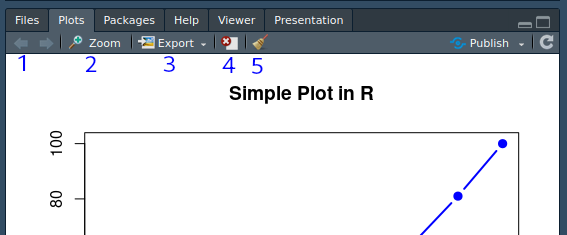

*Botões da aba Plot*

## 6.3 A função `plot()`

A principal função do sistema de plotagem básico do R é a função `plot()`. Esta é uma função genérica e o seu resultado depende do tipo de objeto que ela recebe.

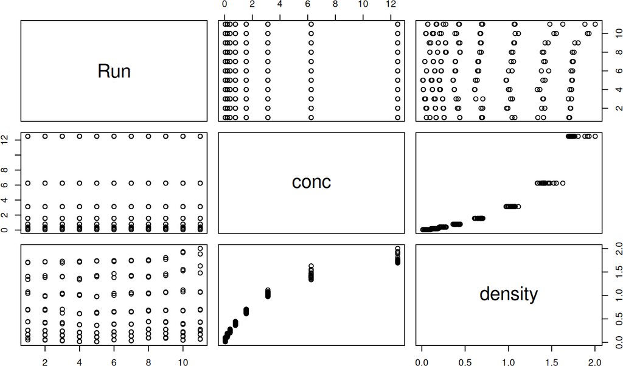

```r
plot(DNase)
```

A função `plot()` irá plotar gráficos combinando todas as variáveis presentes no data.frame. Apesar de ser útil para termos uma visão geral sobre como as variáveis se relacionam entre si, este tipo de gráfico não é indicado para comunicar nossos resultados com o público.

Alternativamente, podemos estabelecer as variáveis que desejamos para avaliar. Vamos criar um gráfico de dispersão para avaliar a relação entre duas variáveis: a concentração da enzima no soro (`conc`) e a densidade estimada (`density`). Para isso, passamos para os eixos *x* e *y* do gráfico as colunas do dataframe:

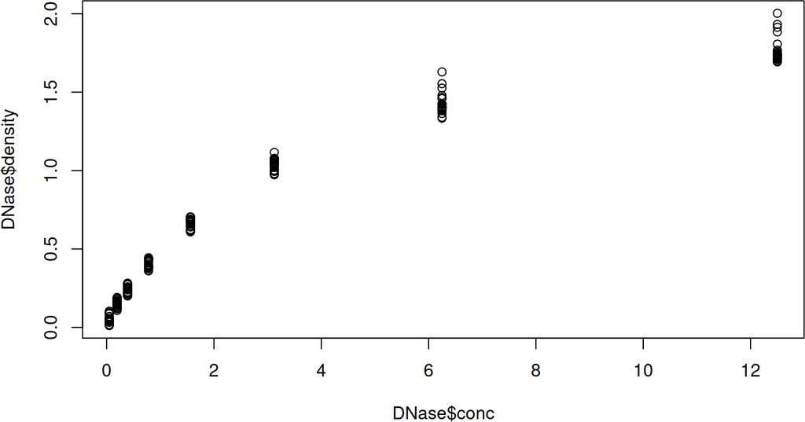

```r
plot(x = DNase$conc, y = DNase$density)
```

### 6.3.1 Argumentos da função `plot()`

A função `plot()` é útil para a construir gráficos que relacionem duas variáveis. Ao determinar as variáveis do data.frame a serem plotadas, a função se encarrega de plotar automaticamente os nomes dos eixos, o intervalo de cada eixo, o tipo de ponto a ser presentado. Entretanto, todas estas características podem ser customizadas.

Além dos argumentos `x` e `y` (os eixos do gráfico), a função `plot()` recebe outros argumentos:

- `type`: tipo de plot a ser criado (padrão: “p”, ou gráfico de dispersão)
  - p: pontos
  - l: linhas
  - b: linhas e pontos
  - n: não plotar nada
- `main`: título do gráfico
- `sub`: subtítulo do gráfico
- `xlab`: nome do eixo *x*
- `ylab`: nome do eixo *y*

A função `plot()` pode receber ainda outros argumentos secundários relacionados aos parâmetros estéticos do gráfico. Podemos visualizá-los por meio da função `par()`.

```r
names(par())
```

```
##  [1] "xlog"      "ylog"      "adj"       "ann"       "ask"       "bg"
##  [7] "bty"       "cex"       "cex.axis"  "cex.lab"   "cex.main"  "cex.sub"
## [13] "cin"       "col"       "col.axis"  "col.lab"   "col.main"  "col.sub"
## [19] "cra"       "crt"       "csi"       "cxy"       "din"       "err"
## [25] "family"    "fg"        "fig"       "fin"       "font"      "font.axis"
## [31] "font.lab"  "font.main" "font.sub"  "lab"       "las"       "lend"
## [37] "lheight"   "ljoin"     "lmitre"    "lty"       "lwd"       "mai"
## [43] "mar"       "mex"       "mfcol"     "mfg"       "mfrow"     "mgp"
## [49] "mkh"       "new"       "oma"       "omd"       "omi"       "page"
## [55] "pch"       "pin"       "plt"       "ps"        "pty"       "smo"
## [61] "srt"       "tck"       "tcl"       "usr"       "xaxp"      "xaxs"
## [67] "xaxt"      "xpd"       "yaxp"      "yaxs"      "yaxt"      "ylbias"
```

Dentre os mais usados, temos:

- `col`: define cores dos elementos do gráfico
- `cex`: número (em proporção) que um elemento gráfico deve ser aumentado ou diminuído
- `lwd`: espessura das linhas plotadas
- `lty`: tipo de linha plotada:
  - 0: linhas em branco
  - 1: sólida
  - 2: tracejada; etc.
- `las`: estilo dos nomes dos eixos:
  - 0: sempre paralela ao eixo
  - 1: sempre horizontal
  - 2: sempre perpendicular
  - 3: sempre vertical
- `pch`: tipo de ponto; etc

Com estes argumentos, podemos ter o controle de alguns aspectos do nosso gráfico.

### 6.3.2 Plotando novamente o gráfico de dispersão

De acordo com os parâmetros vistos anteriormente, vamos plotar novamente nosso gráfico de dispersão customizando estes parâmetros.

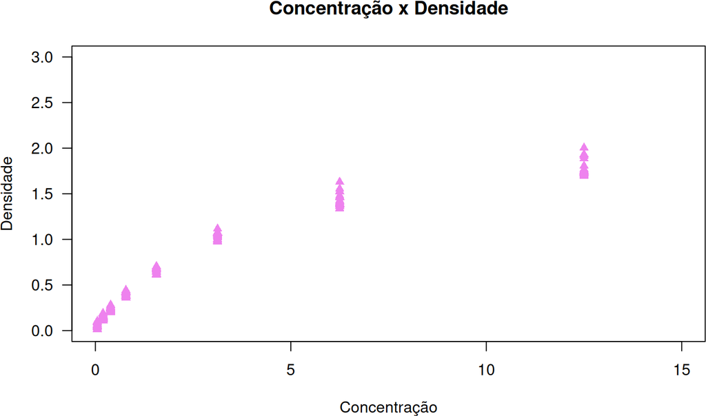

```r
plot(DNase$conc, DNase$density,
     main = "Concentração x Densidade", xlab = "Concentração",
     ylab = "Densidade", pch = 17, col = "violet",
     xlim = c(0, 15), ylim = c(0, 3), las = 1)
```

O pacote básico do R possui uma paleta de cores própria que podem ser usadas para colorir os objetos gráficos produzidos. Ela pode ser listada pela função `colors()`:

```r
head(sample(colors()))
```

```
## [1] "gray79"    "grey60"    "grey86"    "salmon4"   "grey43"    "gainsboro"
```

### 6.3.3 Funções auxiliares

Como vimos, a função `plot()` é a principal função para a construção de gráficos. Entretanto, existem outras funções que controlam isoladamente parâmetros da função `plot()`. Dentre elas, temos:

- `points()`: plota um conjunto de pontos ao gráfico
- `lines()`: plota linhas ao gráfico
- `title()`: define o título do gráfico
- `legend()`: define as legendas do gráfico
- `abline()`: plota uma linha de referência ao gráfico (por exemplo, uma linha média)

Estas funções são complementares à função `plot()`. Esta, quando usada, dá origem a um novo gráfico e as funções auxiliares citadas acima passam a plotar as informações sobre o gráfico já criado.

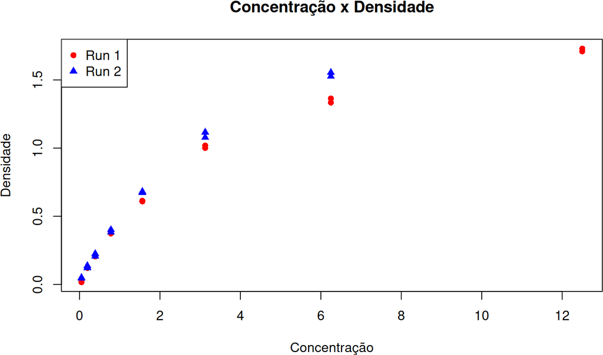

```r
# Fazendo o subset do dataset para as duas corridas
run1 <- DNase[DNase$Run == 1,]
run2 <- DNase[DNase$Run == 2,]

# Plotar primeiro a corrida 1 (run1)
plot(run1$conc, run1$density, col = "red",
     pch = 16, xlab = "Concentração", ylab = "Densidade")

# Adicionar título ao gráfico
title("Concentração x Densidade")

# Com a função points(), adicionar ao gráfico os pontos da corrida 2 (run2)
points(run2$conc, run2$density, col = "blue",
       pch = 17, xlab = "Concentração", ylab = "Densidade")

# Adicionar a legenda
legend(x = "topleft", col = c("red", "blue"), pch = c(16, 17),
       legend = c("Run 1", "Run 2"))
```

#### 6.3.3.1 Testando um modelo linear

Vamos criar um gráfico de dispersão e adicionar a ele o modelo linear da relação entre as duas variáveis.

```r
set.seed(20)

# Criando a variável x
x <- rnorm(100)
e <- rnorm(100, 0, 2)

# Criando a variável y
y <- 0.5 + 2 * x + e

# Plotando
plot(x, y, xlab = "x", ylab = "y")

# Usando a função lm() para criar um modelo linear que explica a relação entre x e y.
model <- lm(y ~ x)
summary(model)
```

```
##
## Call:
## lm(formula = y ~ x)
##
## Residuals:
##     Min      1Q  Median      3Q     Max
## -3.9170 -1.3303  0.1328  1.5261  3.6446
##
## Coefficients:
##             Estimate Std. Error t value Pr(>|t|)
## (Intercept)   0.6777     0.1983   3.417 0.000922 ***
## x             2.3596     0.2013  11.719  < 2e-16 ***
## ---
## Signif. codes:  0 '***' 0.001 '**' 0.01 '*' 0.05 '.' 0.1 ' ' 1
##
## Residual standard error: 1.983 on 98 degrees of freedom
## Multiple R-squared:  0.5836, Adjusted R-squared:  0.5793
## F-statistic: 137.3 on 1 and 98 DF,  p-value: < 2.2e-16
```

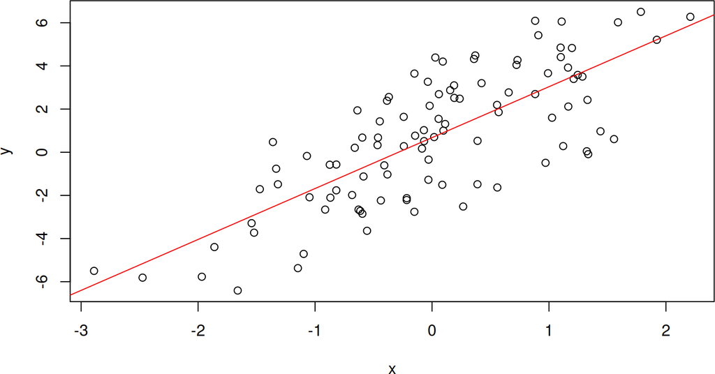

```r
# Usando a função abline() para adicionar o modelo ao gráfico
abline(model, lwd = 1, col = "red")
```

## 6.4 Outras funções importantes

Além da função `plot()`, há outras funções importantes que permitem a construção de outros tipos de gráficos além dos gráficos de dispersão. Estas funções possuem seus argumentos particulares, mas de forma geral, os gráficos construídos podem ser personalizados de acordo com os parâmetros já discutidos anteriormente.

### 6.4.1 Criando um gráfico de barras com `barplot()`

Vamos usar o dataset `mtcars` para criar um gráfico de barras que represente o peso dos carros. Para isso, usamos a função `barplot()`. Para criar o gráfico de barras, devemos ter um **vetor numérico**:

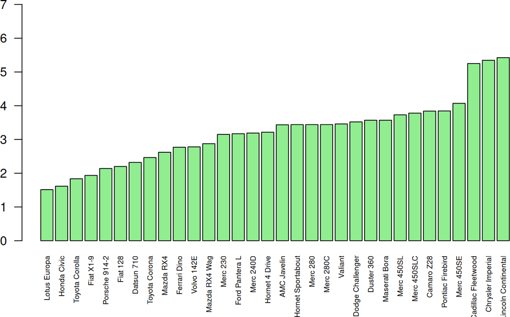

```r
# Ordenar os valores
mtcars <- mtcars[order(mtcars$wt),]

# Plotar
barplot(mtcars$wt, las = 2, names.arg = rownames(mtcars), cex.names = 0.6, ylim = c(0, 7), col = "lightgreen")
```

#### 6.4.1.1 Adicionando barras de erro

Vamos adicionar as barras de erro no topo de cada barra em um gráfico de barras.

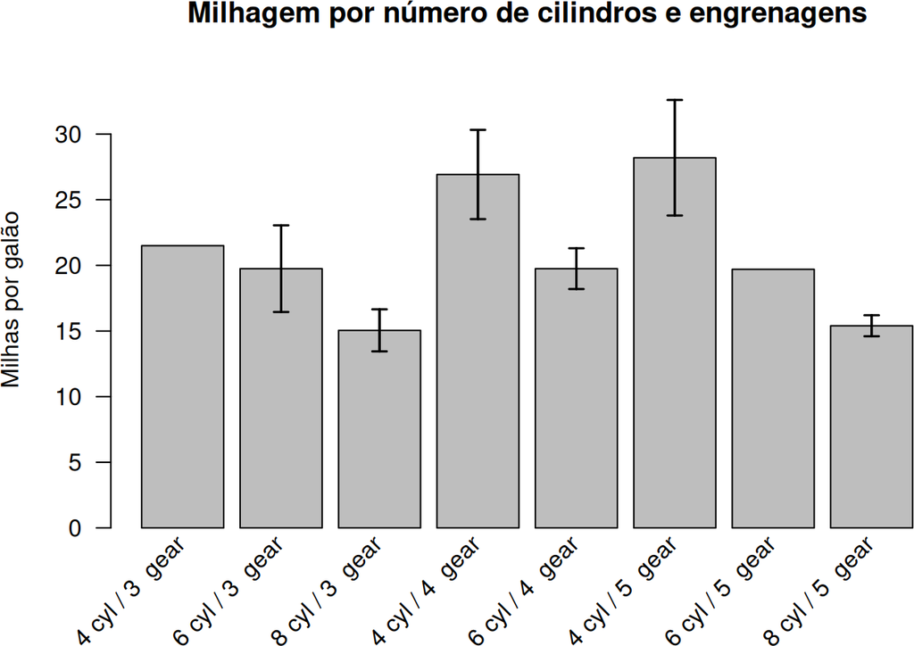

```r
# Criar um dataframe myData com as informacoes da media, desvio padrao e quantidade de elementos
# para cada categoria de cilindros e gear
myData <- aggregate(mtcars$mpg,
                    by = list(cyl = mtcars$cyl, gears = mtcars$gear),
                    FUN = function(x) c(mean = mean(x), sd = sd(x),
                                        n = length(x)))

# Criar colunas para a media, desvio padrao e quantidade de elementos
myData <- do.call(data.frame, myData)

# Calcular o erro
myData$se <- myData$x.sd / sqrt(myData$x.n)

# Nomear as colunas
colnames(myData) <- c("cyl", "gears", "mean", "sd", "n", "se")

# Nomear os grupos
myData$names <- c(paste(myData$cyl, "cyl /",
                        myData$gears, " gear"))

# Organizar as margens para caber todos os valores
par(mar = c(5, 6, 4, 5) + 0.1)

# Calcular o valor maximo de y para caber os valores da barra de erro
plotTop <- max(myData$mean) +
    myData[myData$mean == max(myData$mean), 6] * 3

# Plotar o grafico e obter os valores do centro de cada barra
barCenters <- barplot(height = myData$mean,
                      names.arg = myData$names,
                      beside = true, las = 2,
                      ylim = c(0, plotTop),
                      cex.names = 0.75, xaxt = "n",
                      main = "Milhagem por número de cilindros e engrenagens",
                      ylab = "Milhas por galão",
                      border = "black", axes = TRUE)


# Adicionar o texto do eixo x
text(x = barCenters, y = par("usr")[3] - 1, srt = 45,
     adj = 1, labels = myData$names, xpd = TRUE)

# Adicionar os segmentos
segments(barCenters, myData$mean - myData$se * 2, barCenters,
         myData$mean + myData$se * 2, lwd = 1.5)

# Adicionar as barras superiores
arrows(barCenters, myData$mean - myData$se * 2, barCenters,
       myData$mean + myData$se * 2, lwd = 1.5, angle = 90,
       code = 3, length = 0.05)
```

### 6.4.2 Criando um boxplot com `boxplot()`

Vamos agora ter uma ideia da distribuição dos dados em uma ou mais variáveis. Para isso, podemos usar o boxplot.

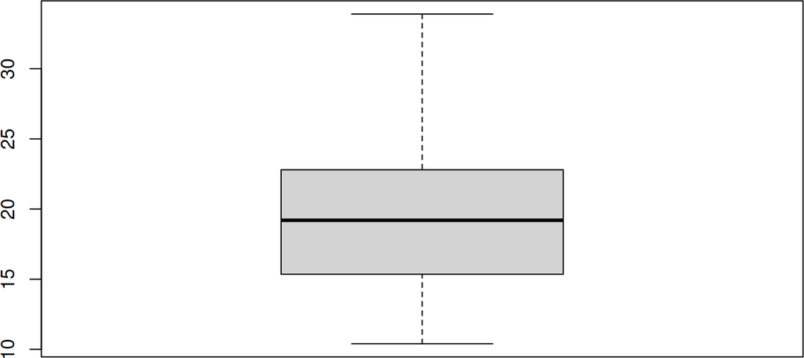

```r
boxplot(mtcars$mpg)
```

Além disso, podemos plotar a distribuição do consumo (`mpg`) em função da quantidade de cilindros de cada carro (`cyl`), usando a notação `mtcars$mpg ~ mtcars$cyl`, que quer dizer: *a variável `mpg` em função da variável `cyl`.*

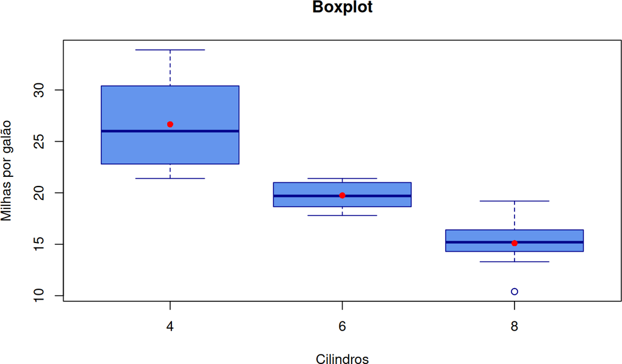

```r
# Plotar o boxplot
boxplot(formula = mtcars$mpg ~ mtcars$cyl, main = "Boxplot",
        xlab = "Cilindros", ylab = "Milhas por galão",
        col = "cornflowerblue", border = "darkblue")

# Calcular média
media <- tapply(mtcars$mpg, mtcars$cyl, mean)

# Plotar a média
points(media, pch = 16, col = "red")
```

### 6.4.3 Criando um histograma com `hist()`

O histograma também é conhecido como gráfico de distribuição de frequências.

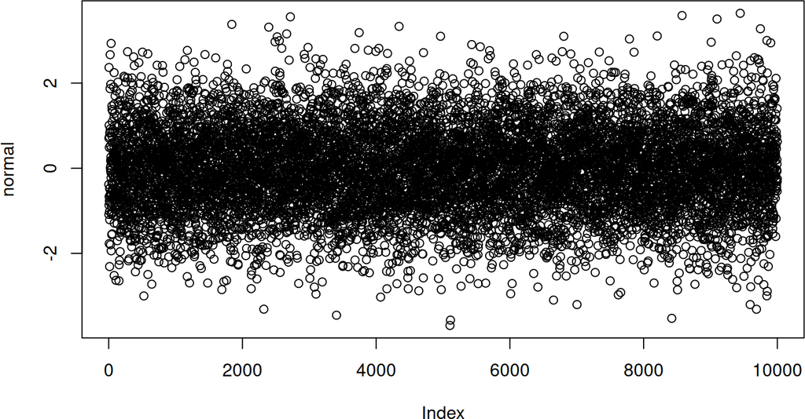

```r
# Simular um vetor numérico que apresente uma distribuição normal
normal <- rnorm(10000, mean = 0, sd = 1)

# Plotar gráfico de dispersão
plot(normal)
```

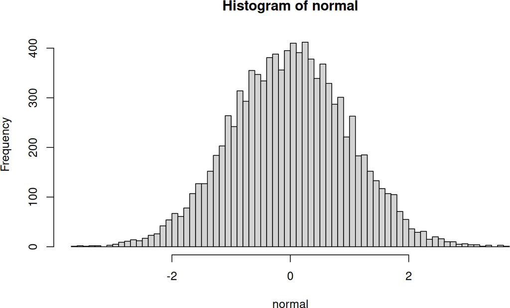

```r
# Plotar o histograma
hist(normal, breaks = 100)
```

O dataset `airquality` mostra dados da qualidade do ar na cidade de Nova York. Vamos avaliar a distribuição da concentração de ozônio na cidade durante o período observado.

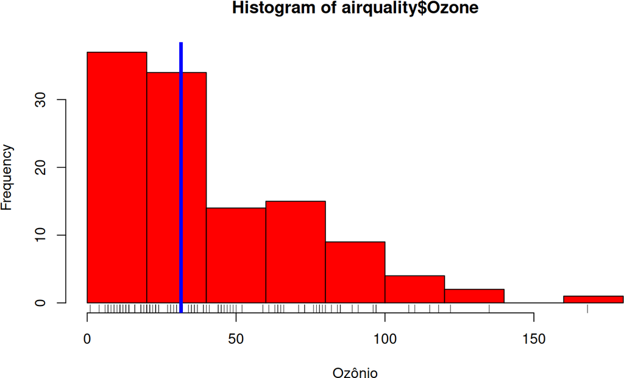

```r
# Plotar histograma
hist(airquality$Ozone, col = "red", xlab = "Ozônio")

# Plotar as observações
rug(airquality$Ozone)

# Plotar a mediana
abline(v = median(airquality$Ozone, na.rm = T),col = "blue", lwd = 4)
```

## 6.5 Trabalhando com a função `par()`

A função `par()` contém diversos elementos estéticos dos gráficos. Seus argumentos podem ser usados nas funções principais, como na função `plot()`. Entretanto, a função `par()` pode ser usada para setar de forma global os parâmetros dos gráficos criados. Por exemplo: `par(col = "red")` irá setar a coloração de todos os gráficos criados adiante na cor vermelha.

Uma função útil desse recurso é o uso do parâmetro `mfrow`. Este permite plotar gráficos lado a lado. Ele recebe um vetor numérico de dois elementos, que representam o número de linhas e de colunas que representação deverá ter:

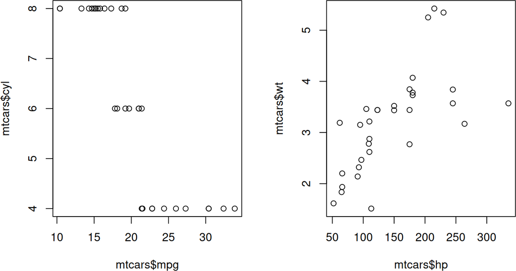

```r
# Plotar dois gráficos lado a lado (1 linha e 2 colunas)
par(mfrow = c(1, 2))

# Plotar os gráficos
plot(mtcars$mpg, mtcars$cyl)
plot(mtcars$hp, mtcars$wt)
```

## 6.6 Salvando os gráficos em arquivos

Após a construção dos gráficos, pode-se salvá-los por meio do botão exportar na aba *Plots* do RStudio. A própria aba *Plots* é um dispositivo de visualização (*device*). Existem outros devices, que fornecem outras formas de visualizar e salvar os gráficos criados. Dentre eles, temos as funções `pdf()`, `png()` e `jpeg()`, por exemplo. Aqui está um exemplo do uso da função `pdf()` para salvar um plot criado em formato pdf:

```r
# Criar um arquivo "plot1.pdf". Ele será criado no diretório de trabalho atual.
pdf(file = "plot1.pdf", width = 10, height = 10)

# Plotar gráficos
plot(mtcars$mpg)
hist(mtcars$wt)
barplot(mtcars$wt)

# Fechar a conexão com o device
dev.off()
```

Com isso, os gráficos até o fechamento do device (`dev.off()`) serão salvos no arquivo criado. O mesmo pode ser feito com as funções `png()` e `jpeg()` para salvar os gráficos nos formatos png e jpeg.

## 6.7 Gráficos com matrizes

Pode-se representar os dados presentes em objetos multimensionais, como as matrizes.

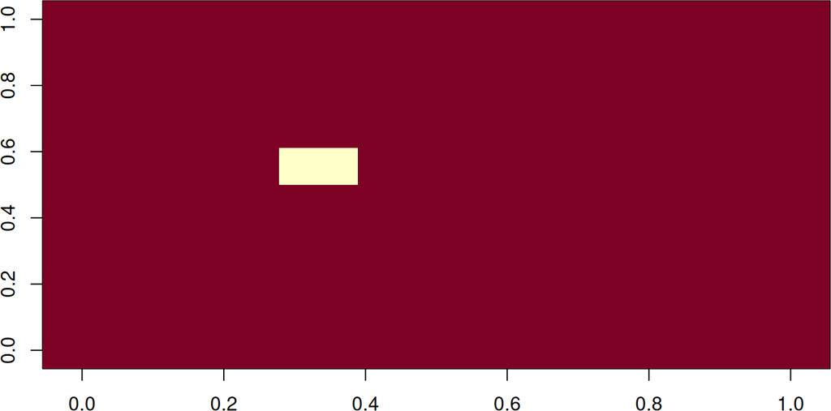

```r
# Construir uma matriz
mt <- matrix(1, 10, 10)
mt[4, 6] <- 0

# Construir uma imagem da matriz
image(mt)
```

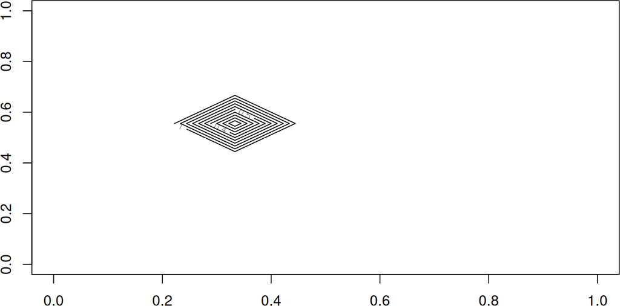

```r
# Plot do contorno da matriz
contour(mt)
```

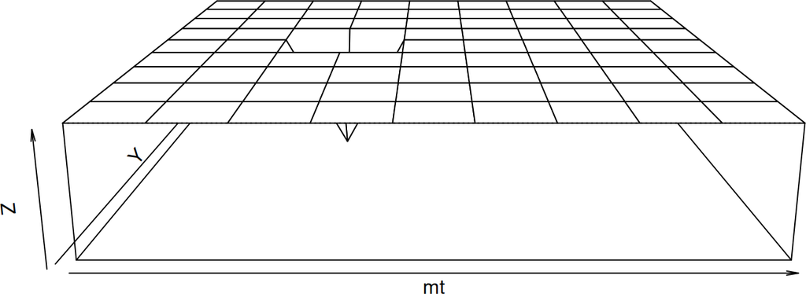

```r
# Plot da matriz em perspectiva
persp(mt, expand = 0.2)
```

A matriz `volcano` possui informações sobre o relevo de um vulcão ativo na Nova Zelândia.

```r
head(volcano)
```

```
##      [,1] [,2] [,3] [,4] [,5] [,6] [,7] [,8] [,9] [,10] [,11] [,12] [,13] [,14]
## [1,]  100  100  101  101  101  101  101  100  100   100   101   101   102   102
## [2,]  101  101  102  102  102  102  102  101  101   101   102   102   103   103
## [3,]  102  102  103  103  103  103  103  102  102   102   103   103   104   104
## [4,]  103  103  104  104  104  104  104  103  103   103   103   104   104   104
## [5,]  104  104  105  105  105  105  105  104  104   103   104   104   105   105
## [6,]  105  105  105  106  106  106  106  105  105   104   104   105   105   106
##      [,15] [,16] [,17] [,18] [,19] [,20] [,21] [,22] [,23] [,24] [,25] [,26]
## [1,]   102   102   103   104   103   102   101   101   102   103   104   104
## [2,]   103   103   104   105   104   103   102   102   103   105   106   106
## [3,]   104   104   105   106   105   104   104   105   106   107   108   110
## [4,]   105   105   106   107   106   106   106   107   108   110   111   114
## [5,]   105   106   107   108   108   108   109   110   112   114   115   118
## [6,]   106   107   109   110   110   112   113   115   116   118   119   121
##      [,27] [,28] [,29] [,30] [,31] [,32] [,33] [,34] [,35] [,36] [,37] [,38]
```

[output cut: 20 more lines]

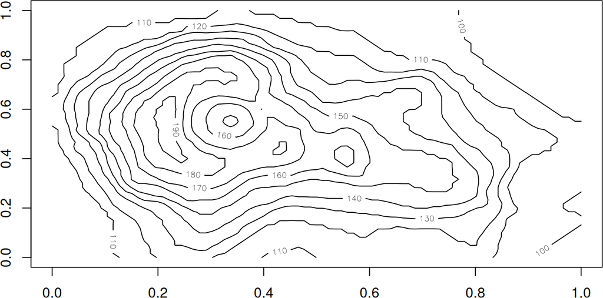

```r
# Contorno
contour(volcano)
```

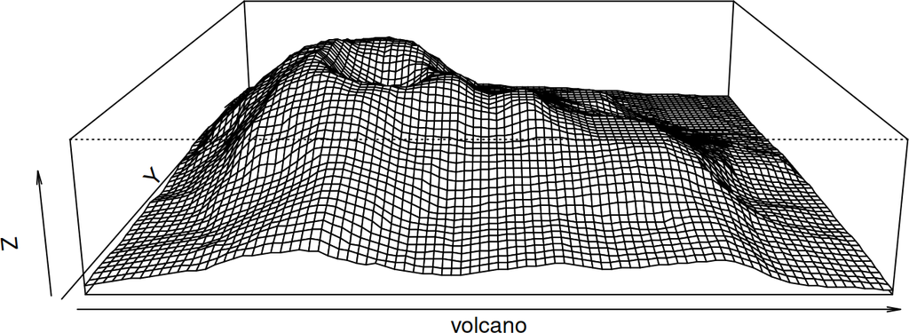

```r
# Perspectiva
persp(volcano, expand = 0.2)
```

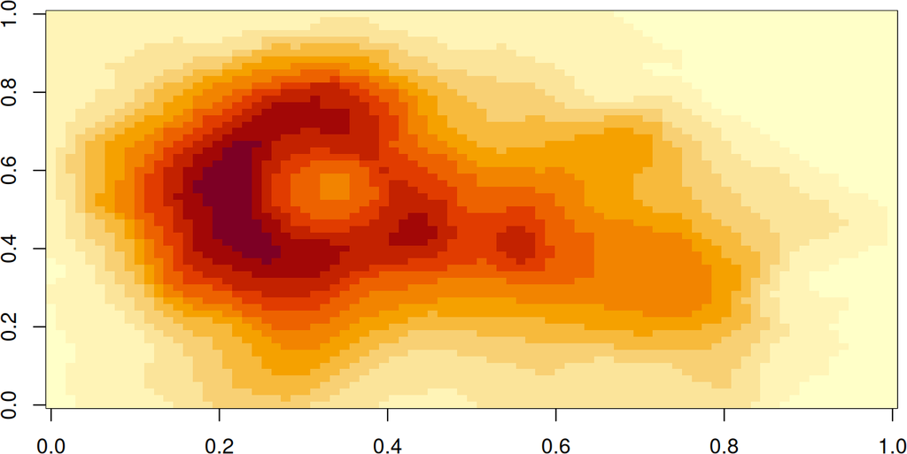

```r
# Imagem
image(volcano)
```

# 7 Pacotes em R

## 7.1 Instalação de pacotes

Pacotes agrupam funções projetadas para atacar um problema específico. Como exemplo é possível citar o pacote `data.table` do [CRAN](https://cran.r-project.org/), que possui funções para manipulação de grandes quantidades de dados. Pacotes disponíveis em repositórios (como o CRAN, Bioconductor e Github) podem ser instalados por meio de poucas linhas de comando.

Verificando se um pacote já está instalado:

```r
require(affy)
```

O [CRAN](https://cran.r-project.org/) é o principal repositório de pacotes do R e possui pacotes com finalidades variadas: importação e exportação de dados, manipulação de grafos, desenvolvimento de pacotes, plotagem, paralelismo.

Instalando o pacote `devtools` do CRAN:

```r
install.packages("devtools")
```

O [Bioconductor](http://bioconductor.org/) é o principal repositório de pacotes voltados para a bioinformática. Todo pacote do Bioconductor é classificado em uma de três categorias: pacote de anotação (bancos de dados e dicionários), pacote de dados de experimentos (datasets relacionados a um experimento) ou pacote de software (funcionalidades).

Instalando o pacote `geneplast` do Bioconductor:

```r
# tente http:// caso URLs https:// URLs não sejam suportadas
source("https://bioconductor.org/biocLite.R")
biocLite("geneplast")
```

O [Github](https://github.com/) é um repositório usado por desenvolvedores, individualmente ou em equipe, e possui pacotes feitos em diversas linguagens.

Instalando o pacote `transcriptogramer` a partir do Github (requer o pacote `devtools`):

```r
# carrega o pacote devtools
library(devtools)
# o pacote transcriptogramer pertence ao usuário arthurvinx
install_github("arthurvinx/transcriptogramer")
```

A instalação a partir do Github pode ser problemática, pois sistemas operacionais diferentes requerem a instalação de dependências diferentes. O Windows, por exemplo, requer a instalação do [Rtools](https://cran.r-project.org/bin/windows/Rtools/). Como o Github é um repositório pessoal, alguns pacotes podem não conter vinhetas, ou necessitam do argumento adicional da função `install_github()`, `build_vignettes = T`, para que a vinheta seja construída. Apesar destas barreiras, alguns pacotes encontram-se disponíveis apenas no Github, por falta de interesse do desenvolvedor em publicar o pacote no CRAN/Bioconductor, ou pela dificuldade em cumprir os requisitos impostos pelos repositórios.

## 7.2 Exploração de pacotes

Todos os pacotes do Bioconductor possuem uma vinheta, um documento que apresenta a finalidade do pacote. A vinheta de um pacote pode ser visualizada com a função `vignette()`:

```r
# transcriptogramer pode ser substituído pelo nome de qualquer outro pacote instalado
vignette("transcriptogramer")
```

Pacotes também possuem documentações detalhadas das suas funções. Na vinheta do pacote `transcriptogramer` é utilizado o dataset `GPL570` e a função `clusterEnrichment()`, para saber mais detalhes podem ser usados os comandos de ajuda:

```r
??clusterEnrichment
??GPL570
??transcriptogramer
```

Também é possível navegar pela documentação utilizando a aba `Help` do `RStudio.`

Para saber como um pacote deve ser citado num artigo utilize a função `citation()`:

```r
citation("transcriptogramer")
```

## 7.3 Princípios de construção de pacotes em R

O `RStudio` oferece a opção de criação de pacotes com a opção `File > New Project`. Ao utilizar esta opção é criada a estrutura básica de um pacote:

- DESCRIPTION: Um arquivo de texto a ser editado com as informações do pacote, tais como versão, pacotes requeridos, autores e descrição. As informações deste arquivo são usadas para verificar o conteúdo do pacote e para instalá-lo. A regra de versionamento sugere que a versão do pacote seja composta por `X`.`Y`.`Z`, sendo o `Z` incrementado a cada alteração, o `Y` sendo incrementado a cada lançamento ou adição de funcionalidades, e o `X` sendo incrementado em casos raros de mudanças bruscas ou grandes alterações.
- NAMESPACE: Este arquivo descreve tudo que é importado e exportado pelo pacote, e `nunca deve ser editado manualmente`. Este arquivo é essencial e deve ser consistente com o que o pacote utiliza e o que se deseja disponibilizar para os usuários. Para descrever isto é necessário o uso de [`comentários roxygen`](https://cran.r-project.org/web/packages/roxygen2/vignettes/rd.html), interpretados pelo pacote `roxygen2` do CRAN para gerar a documentação das funções.
- man: Um diretório que armazena a documentação das funções. Seu conteúdo é gerado e atualizado pela função `document()` do pacote `devtools`, que gera arquivos `.Rd` a partir de `comentários roxygen`. A função `document()` também atualiza o conteúdo do arquivo `NAMESPACE`.
- R: Todos os arquivos `.R`, contendo códigos referentes às funcionalidades, devem ser armazenados neste diretório.

Outros diretórios podem ser criados manualmente ou por funções.

- vignettes: Criado pela função `use_vignette()` do pacote `devtools`, armazena arquivos para a geração da vinheta.
- inst/doc: Os diretórios `inst` e `doc` podem ser gerados pela função `build_vignettes()` do pacote `devtools`. O diretório `inst` pode ser utilizado para armazenar o arquivo `CITATION`, `NEWS` e testes unitários além de armazenar o diretório `doc`.
- src: Este diretório é utilizado para armazenar arquivos feitos em outras linguagens, como arquivos feitos em `C` ou `C++`.
- data: Este diretório é utilizado para armazenar todos os arquivos binários referentes aos datasets do pacote.

# 8 Referências

[Peng, Roger D.. **R Programming for Data Science**. 2016](https://leanpub.com/rprogramming)

[Peng, Roger D.. **Exploratory Data Analysis with R**. 2016](https://leanpub.com/exdata)